# Cytochrome C551 Peroxidase

Fold-switch pair **4aalA_4aanA** — **4aalA** vs **4aanA**

Geobacter sulfurreducens PCA

## Figure 1: Phylogenetic tree with per-cluster fold-preference heatmap.

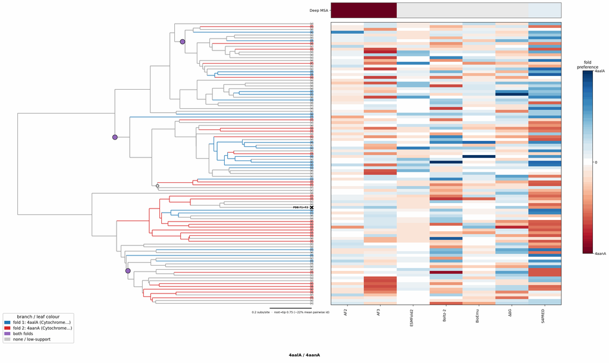

## Figure 2: Aligned overlay (both folds superposed)

The single fold-switching chain of each fold superposed by TM-align; waters hidden, any ligand shown as green sticks. Grey = structurally conserved core, colour = divergent (fold-switching) region.

4aalA (Cytochrome C551 Peroxidase)4aanA (Cytochrome C551 Peroxidase)Ligand EOH|HEC (bound to 4aalA), Ligand BU3|HEC (bound to 4aanA)

TM-score: 0.877 · Trigger class: ligand

Aligned overlay

## Figure 3: The two folds, side by side

Each fold is coloured by per-residue Cα deviation between the two superposed structures: grey ≈ conserved core, full colour = structurally divergent (fold-switching) region.

4aalA (Cytochrome C551 Peroxidase)

4aanA (Cytochrome C551 Peroxidase)

0 Å5≥10 Å

4aalA (Cytochrome C551 Peroxidase)

4aanA (Cytochrome C551 Peroxidase)

## Figure 4: Best-cluster predicted contact maps over the two true folds.

Predicted contact maps (MSA-Transformer) for the clusters best matching each fold, over the true contacts of fold 1 (upper triangle) and fold 2 (lower). Divergent contacts between clusters are the contact-level signature of fold-switching.

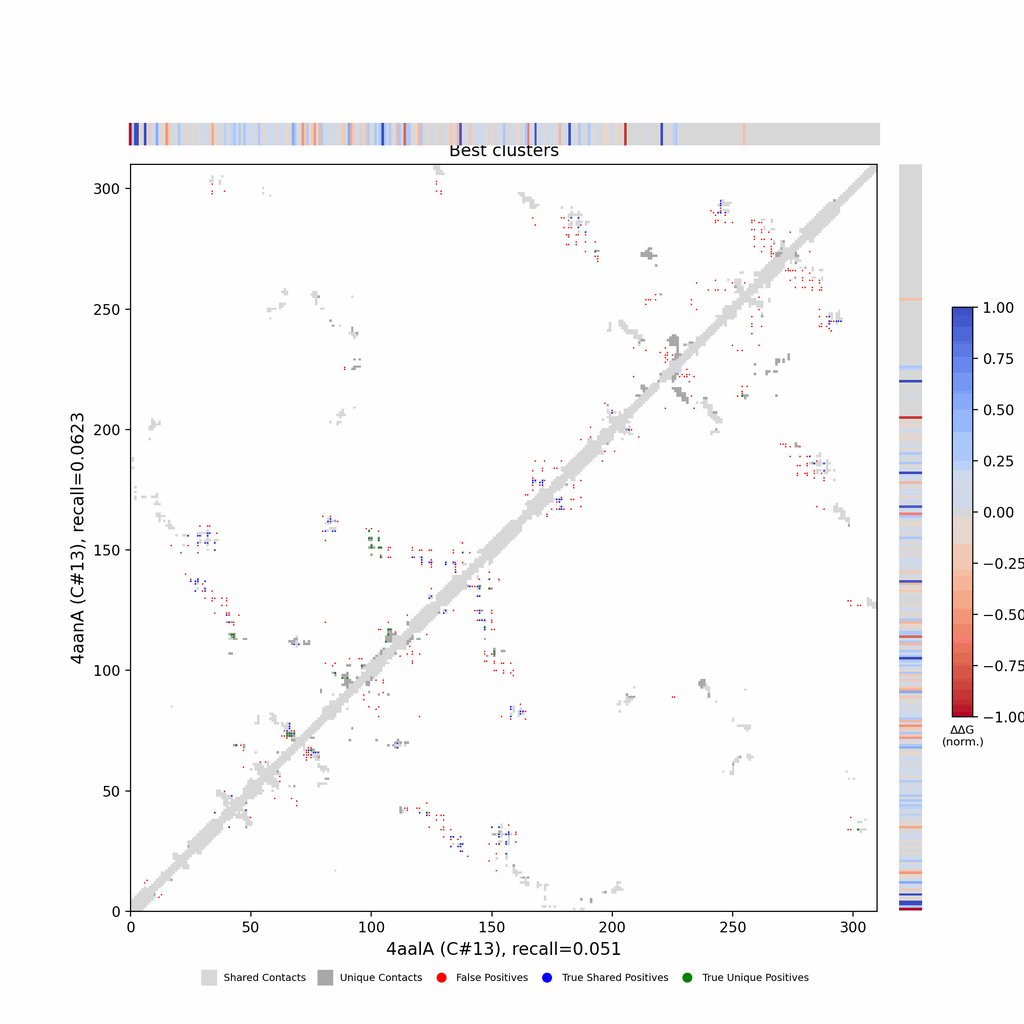

## Figure 5: Per-residue ΔΔG fold-preference contribution

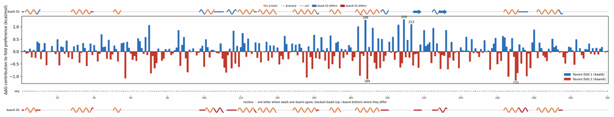

**More figures**

## Figure 6: Deep-MSA contact map panel / Best clusters contact map panel

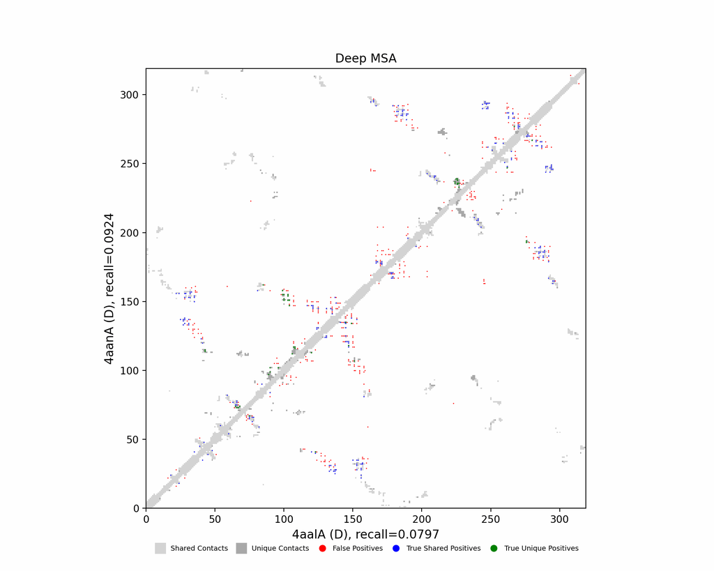

Deep-MSA contact map panel

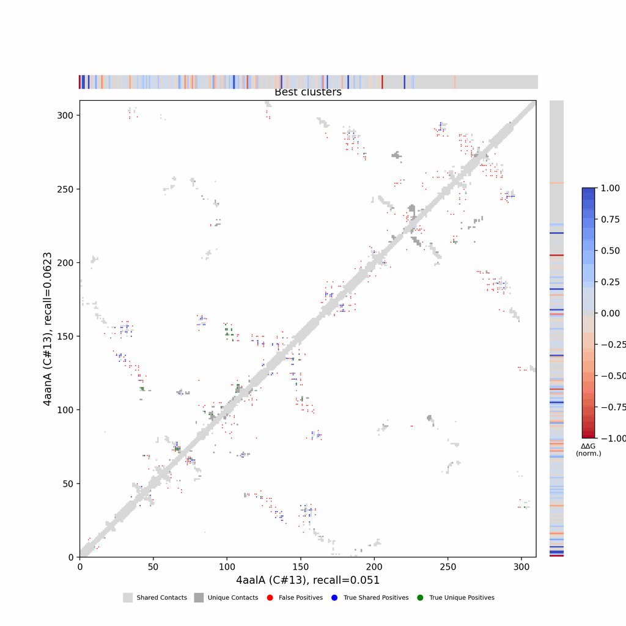

Best clusters contact map panel

## Figure 7: All clusters contact-map mosaic (small multiples).

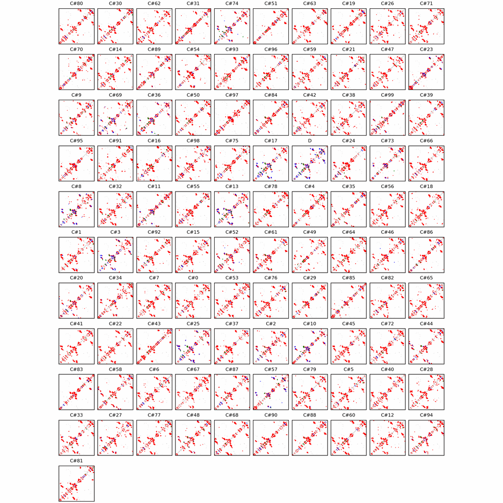

## Figure 8: Phylo null: tree with shuffled cluster fold labels.

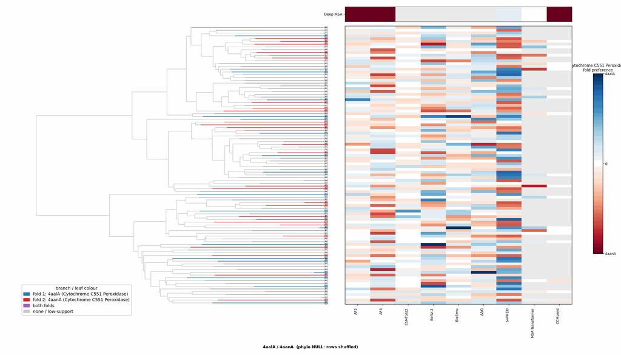

## Cluster metrics table

Per-cluster metrics underlying the figures above.

| cluster | n | neff | AF2_TM1 | AF2_TM2 | AF3_TM1 | AF3_TM2 | RE-MSAT-COM | RE-MSAT1 | RE-MSAT2 | ESM_SEQIDS | ESM_TM1 | ESM_TM2 | ΔΔG_Bias | ΔΔG_Bias_std | ΔΔG_frac_F1 | Boltz2_pref | S4PRED_pref | CCMpred_pref | BioEmu_pref |
| --- | --- | --- | --- | --- | --- | --- | --- | --- | --- | --- | --- | --- | --- | --- | --- | --- | --- | --- | --- |
| Deep | - | - | 0.88 | 0.99 | 0.88 | 1.0 | 0.29 | 0.27 | 0.31 | - | - | - | - | - | - | - | 0.0 | -0.04 | - |
| 000 | 2295.0 | 1549.0 | 0.38 | 0.38 | 0.68 | 0.75 | 0.01 | 0.01 | 0.01 | 001; 001; 008; 007; 008; 007; 006; 006; 005; 005 | 0.76 ± 0.05 | 0.85 ± 0.05 | -1.01 | 6.34 | 0.4 | -0.01 | -0.0 | -0.0 | 0.0 |
| 001 | 1452.0 | 861.0 | 0.41 | 0.42 | 0.73 | 0.82 | 0.03 | 0.03 | 0.02 | 001; 006; 006; 001; 005; 008; 002; 002; 005; 008 | 0.76 ± 0.01 | 0.84 ± 0.02 | 0.63 | 5.8 | 0.5 | -0.0 | -0.01 | -0.0 | -0.01 |
| 002 | 1240.0 | 814.0 | 0.32 | 0.31 | 0.38 | 0.38 | 0.05 | 0.04 | 0.06 | 001; 001; 005; 004; 004; 005; 006; 006; 002; 002 | 0.76 ± 0.05 | 0.84 ± 0.05 | 0.34 | 6.58 | 0.6 | -0.01 | 0.0 | -0.0 | 0.0 |
| 003 | 1216.0 | 668.0 | 0.45 | 0.46 | 0.63 | 0.63 | 0.15 | 0.13 | 0.17 | 001; 001; 002; 002; 009; 009; 007; 007; 004; 004 | 0.74 ± 0.01 | 0.83 ± 0.01 | 1.28 | 4.07 | 0.5 | -0.01 | -0.01 | -0.0 | -0.01 |
| 004 | 730.0 | 150.0 | 0.24 | 0.24 | 0.6 | 0.6 | 0.0 | 0.01 | 0.01 | 001; 001; 002; 002; 004; 004; 005; 005; 007; 007 | 0.75 ± 0.02 | 0.83 ± 0.05 | -0.12 | 5.28 | 0.5 | 0.0 | 0.0 | 0.0 | 0.04 |
| 005 | 653.0 | 418.0 | 0.45 | 0.43 | 0.61 | 0.63 | 0.01 | 0.01 | 0.01 | 009; 009; 005; 005; 001; 008; 008; 001; 003; 003 | 0.78 ± 0.01 | 0.86 ± 0.02 | -1.5 | 3.67 | 0.3 | -0.0 | -0.01 | 0.0 | 0.0 |
| 006 | 566.0 | 387.0 | 0.31 | 0.3 | 0.64 | 0.7 | 0.04 | 0.03 | 0.04 | 001; 001; 003; 007; 004; 003; 004; 007; 006; 006 | 0.76 ± 0.01 | 0.84 ± 0.02 | 1.48 | 4.06 | 0.7 | -0.01 | 0.0 | 0.0 | 0.01 |
| 007 | 547.0 | 360.0 | 0.41 | 0.4 | 0.61 | 0.66 | 0.0 | 0.0 | 0.01 | 001; 001; 006; 006; 008; 008; 002; 002; 003; 003 | 0.80 ± 0.04 | 0.89 ± 0.05 | 1.28 | 5.3 | 0.6 | -0.0 | -0.0 | 0.0 | -0.01 |
| 008 | 522.0 | 327.0 | 0.3 | 0.31 | 0.35 | 0.36 | 0.13 | 0.12 | 0.14 | 002; 003; 009; 008; 003; 002; 008; 009; 001; 001 | 0.74 ± 0.00 | 0.82 ± 0.01 | 1.53 | 3.67 | 0.7 | 0.02 | -0.01 | 0.0 | -0.0 |
| 009 | 514.0 | 251.0 | 0.45 | 0.46 | 0.64 | 0.67 | 0.02 | 0.02 | 0.04 | 008; 009; 008; 009; 001; 001; 004; 004; 005; 005 | 0.76 ± 0.03 | 0.84 ± 0.05 | -2.3 | 5.66 | 0.4 | -0.01 | -0.01 | 0.0 | 0.0 |
| 010 | 490.0 | 116.0 | 0.4 | 0.39 | 0.53 | 0.53 | 0.13 | 0.11 | 0.14 | 007; 005; 005; 007; 004; 004; 001; 001; 006; 006 | 0.76 ± 0.02 | 0.84 ± 0.02 | 1.1 | 3.84 | 0.4 | -0.0 | -0.0 | 0.0 | 0.01 |
| 011 | 483.0 | 50.0 | 0.45 | 0.43 | 0.63 | 0.62 | 0.04 | 0.03 | 0.04 | 001; 002; 002; 006; 006; 001; 003; 003; 004; 004 | 0.80 ± 0.07 | 0.87 ± 0.09 | 1.08 | 6.86 | 0.5 | 0.01 | -0.01 | 0.0 | -0.0 |
| 012 | 462.0 | 278.0 | 0.58 | 0.58 | 0.76 | 0.85 | 0.0 | 0.0 | 0.0 | 002; 002; 001; 001; 009; 009; 003; 003; 005; 005 | 0.74 ± 0.10 | 0.82 ± 0.12 | -1.06 | 5.26 | 0.4 | 0.02 | -0.01 | 0.0 | 0.0 |
| 013 | 423.0 | 267.0 | 0.37 | 0.36 | 0.46 | 0.47 | 0.19 | 0.18 | 0.21 | 001; 001; 003; 003; 004; 005; 004; 005; 002; 002 | 0.78 ± 0.05 | 0.85 ± 0.08 | 2.39 | 5.0 | 0.8 | 0.01 | -0.01 | 0.0 | 0.0 |
| 014 | 420.0 | 280.0 | 0.33 | 0.32 | 0.72 | 0.8 | 0.0 | 0.01 | 0.01 | 010; 010; 004; 004; 005; 001; 005; 001; 007; 006 | 0.76 ± 0.01 | 0.84 ± 0.01 | 1.33 | 4.96 | 0.6 | 0.01 | 0.0 | 0.0 | -0.01 |
| 015 | 420.0 | 263.0 | 0.41 | 0.44 | 0.48 | 0.48 | 0.03 | 0.03 | 0.03 | 006; 006; 008; 008; 001; 009; 009; 007; 001; 007 | 0.75 ± 0.02 | 0.84 ± 0.02 | 0.46 | 4.24 | 0.5 | -0.0 | -0.01 | 0.0 | 0.0 |
| 016 | 416.0 | 281.0 | 0.37 | 0.39 | 0.6 | 0.61 | 0.03 | 0.03 | 0.04 | 001; 001; 010; 010; 006; 006; 005; 005; 007; 007 | 0.77 ± 0.04 | 0.86 ± 0.05 | -1.17 | 3.6 | 0.3 | -0.01 | -0.0 | 0.0 | 0.0 |
| 017 | 412.0 | 208.0 | 0.32 | 0.29 | 0.41 | 0.44 | 0.13 | 0.12 | 0.17 | 001; 002; 002; 001; 003; 003; 004; 004; 008; 008 | 0.73 ± 0.10 | 0.81 ± 0.11 | -0.48 | 4.46 | 0.4 | -0.01 | 0.0 | 0.0 | -0.01 |
| 018 | 410.0 | 220.0 | 0.58 | 0.56 | 0.76 | 0.83 | 0.0 | 0.0 | 0.01 | 001; 001; 007; 007; 006; 006; 002; 008; 008; 002 | 0.78 ± 0.03 | 0.86 ± 0.04 | -1.07 | 5.28 | 0.4 | -0.0 | -0.01 | 0.0 | -0.0 |
| 019 | 403.0 | 292.0 | 0.37 | 0.36 | 0.35 | 0.34 | 0.02 | 0.02 | 0.02 | - | - | - | 3.54 | 5.83 | 0.6 | 0.01 | -0.0 | - | -0.01 |
| 020 | 392.0 | 159.0 | 0.29 | 0.29 | 0.64 | 0.64 | 0.04 | 0.03 | 0.05 | - | - | - | -1.89 | 4.26 | 0.3 | 0.0 | 0.0 | - | 0.01 |
| 021 | 377.0 | 181.0 | 0.28 | 0.29 | 0.74 | 0.83 | 0.02 | 0.02 | 0.02 | - | - | - | -0.54 | 6.47 | 0.4 | 0.01 | -0.01 | - | 0.01 |
| 022 | 376.0 | 236.0 | 0.22 | 0.23 | 0.58 | 0.6 | 0.0 | 0.0 | 0.0 | - | - | - | 4.04 | 3.49 | 0.8 | 0.02 | 0.0 | - | -0.0 |
| 023 | 360.0 | 85.0 | 0.39 | 0.39 | 0.42 | 0.42 | 0.04 | 0.03 | 0.03 | - | - | - | -0.44 | 2.85 | 0.6 | 0.0 | -0.01 | - | -0.0 |
| 024 | 345.0 | 268.0 | 0.54 | 0.53 | 0.85 | 0.96 | 0.02 | 0.02 | 0.02 | - | - | - | -2.83 | 4.6 | 0.4 | 0.0 | 0.0 | - | 0.0 |
| 025 | 341.0 | 210.0 | 0.26 | 0.28 | 0.68 | 0.71 | 0.17 | 0.15 | 0.19 | - | - | - | 1.09 | 3.58 | 0.6 | -0.02 | -0.01 | - | -0.0 |
| 026 | 340.0 | 243.0 | 0.34 | 0.35 | 0.34 | 0.33 | 0.01 | 0.01 | 0.01 | - | - | - | 2.42 | 4.55 | 0.6 | 0.01 | -0.0 | - | 0.0 |
| 027 | 338.0 | 198.0 | 0.39 | 0.35 | 0.73 | 0.78 | 0.03 | 0.03 | 0.04 | - | - | - | -1.73 | 4.82 | 0.4 | 0.01 | -0.01 | - | -0.0 |
| 028 | 337.0 | 250.0 | 0.5 | 0.52 | 0.86 | 0.95 | 0.01 | 0.02 | 0.01 | - | - | - | 3.37 | 5.24 | 0.7 | -0.0 | 0.0 | - | 0.0 |

[output cut: 71 more lines]